# projectFile

### Screencast :

https://drive.google.com/file/d/1zg_uEHCkrVQMac92aMm5jAEuZMD31zSw/view?usp=drive_link

```python
import numpy as np
import arviz as az
import pymc as pm
from scipy import stats
import seaborn as sns
import matplotlib.pyplot as plt
import pandas as pd
import pytensor.tensor as pt
import warnings
warnings.filterwarnings('ignore')
```

```
WARNING (pytensor.tensor.blas): Using NumPy C-API based implementation for BLAS functions.
```

```python
def standardize(series):
    return (series - series.mean()) / series.std()
```

### Estimand/Question:

- The goal of this project is to utilize statistical methods to infer the relationship between **House Prices** and **House Size**, with **City** acting as a confounder, using the US Real Estate Prices dataset. By leveraging the concepts taught in class, we aim to rigorously estimate the causal effect of house size on housing prices while accounting for geographic and market-specific variations.
- This project demonstrates the practical application of learned methodologies to address real-world challenges in housing market analysis

### Causal Model

- For the above-mentioned dataset, the DAG which can model our Estimand, and the Treatment-Outcome-Confounder variables is illustrated below:
  - House size (H) is assumed to have a direct causal effect on Price (P).
  - City (A) is assumed to affect both House size (H) and Price (P) directly.

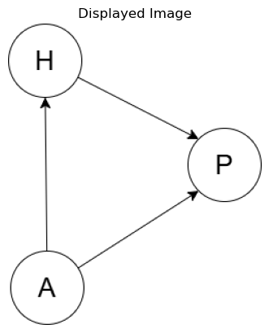

```python
from PIL import Image
import matplotlib.pyplot as plt

# Specify the path to your image
image_path = "./PP.png"

# Open the image using PIL
image = Image.open(image_path)

# Display the image using Matplotlib
plt.imshow(image)
plt.axis('off')  # Hide axes for better display
plt.title("Displayed Image")
plt.show()
```

### Data Import and Pre-Processing

```python
df = pd.read_csv("realtor-data.csv")
df
```

|  | brokered_by | status | price | bed | bath | acre_lot | street | city | state | zip_code | house_size | prev_sold_date |
| --- | --- | --- | --- | --- | --- | --- | --- | --- | --- | --- | --- | --- |
| 0 | 103378.0 | for_sale | 105000.0 | 3.0 | 2.0 | 0.12 | 1962661.0 | Adjuntas | Puerto Rico | 601.0 | 920.0 | NaN |
| 1 | 52707.0 | for_sale | 80000.0 | 4.0 | 2.0 | 0.08 | 1902874.0 | Adjuntas | Puerto Rico | 601.0 | 1527.0 | NaN |
| 2 | 103379.0 | for_sale | 67000.0 | 2.0 | 1.0 | 0.15 | 1404990.0 | Juana Diaz | Puerto Rico | 795.0 | 748.0 | NaN |
| 3 | 31239.0 | for_sale | 145000.0 | 4.0 | 2.0 | 0.10 | 1947675.0 | Ponce | Puerto Rico | 731.0 | 1800.0 | NaN |
| 4 | 34632.0 | for_sale | 65000.0 | 6.0 | 2.0 | 0.05 | 331151.0 | Mayaguez | Puerto Rico | 680.0 | NaN | NaN |
| ... | ... | ... | ... | ... | ... | ... | ... | ... | ... | ... | ... | ... |
| 2226377 | 23009.0 | sold | 359900.0 | 4.0 | 2.0 | 0.33 | 353094.0 | Richland | Washington | 99354.0 | 3600.0 | 2022-03-25 |
| 2226378 | 18208.0 | sold | 350000.0 | 3.0 | 2.0 | 0.10 | 1062149.0 | Richland | Washington | 99354.0 | 1616.0 | 2022-03-25 |
| 2226379 | 76856.0 | sold | 440000.0 | 6.0 | 3.0 | 0.50 | 405677.0 | Richland | Washington | 99354.0 | 3200.0 | 2022-03-24 |
| 2226380 | 53618.0 | sold | 179900.0 | 2.0 | 1.0 | 0.09 | 761379.0 | Richland | Washington | 99354.0 | 933.0 | 2022-03-24 |
| 2226381 | 108243.0 | sold | 580000.0 | 5.0 | 3.0 | 0.31 | 307704.0 | Richland | Washington | 99354.0 | 3615.0 | 2022-03-23 |

2226382 rows × 12 columns

```python
filtered_df = df[['price', 'city', 'house_size']]
filtered_df = filtered_df.dropna()

# Nnumber of Cities to Confound On
n_cities = 10
top_cities = filtered_df['city'].value_counts().head(n_cities).reset_index()
print(top_cities)
top_cities = top_cities['city']

filtered_df = filtered_df[filtered_df['city'].isin(top_cities)]
filtered_df = filtered_df[filtered_df['house_size'] != 1560780.0]

print(filtered_df) # -> Final Data
```

```
            city  count
0        Houston  21700
1        Chicago  12081
2   Jacksonville  10856
3   Philadelphia   9587
4          Miami   9097
5    Los Angeles   8372
6         Tucson   8350
7  New York City   8179
8        Phoenix   7873
9         Dallas   7832
              price           city  house_size
45719     3600000.0  New York City      2338.0
45720    22000000.0  New York City      7020.0
45736     1250000.0  New York City       568.0
45738      395000.0  New York City       650.0
45740     8625000.0  New York City      2617.0
...             ...            ...         ...
2188864     92500.0         Dallas      1082.0
2188884    349900.0         Dallas      1472.0
2188887    420000.0         Dallas      1413.0
2188888    445504.0         Dallas      1440.0
2188907    380000.0         Dallas      1382.0

[103926 rows x 3 columns]
```

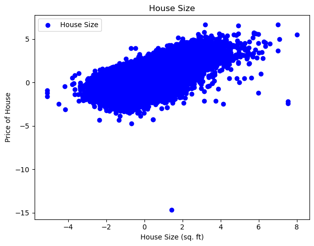

```python
house_size_standardized = standardize(np.log(filtered_df['house_size']))
price_standardized = standardize(np.log(filtered_df['price']))
city = pd.Categorical(filtered_df['city']).codes
city_categories = pd.Categorical(filtered_df['city']).categories
plt.figure(figsize=(12, 5))

# Scatter plot for house_size
plt.subplot(1, 2, 1)
plt.scatter(house_size_standardized, price_standardized, color='blue', label='House Size')
plt.title('House Size')
plt.xlabel('House Size (sq. ft)')
plt.ylabel('Price of House')
plt.legend()
# Display the plots
plt.tight_layout()
plt.show()
```

### Prior Predective Simulation

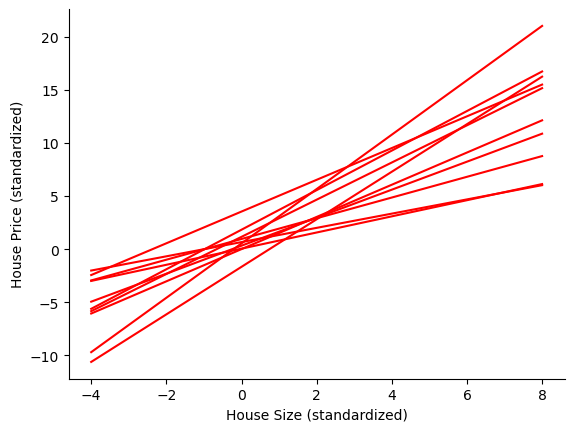

```python
# prior predictive simulation
n = 10
a = stats.norm.rvs(1, 1.5, size=n)
b_a = stats.norm.rvs(1, 1, size=n)
house_price_seq = np.linspace(-4, 8, 40)

for i in range(n):
    mu = a[i] + b_a[i] * house_price_seq
    plt.plot(house_price_seq, mu, color='r')


plt.xlabel("House Size (standardized)")
plt.ylabel("House Price (standardized)")
sns.despine()
```

### Outcome Variable

- The outcome variable, price, is modeled using a Normal distribution:
- This is appropriate for the following reasons:
  - Housing prices are continuous, and their standardized form typically follows a roughly normal distribution.
  - The standard deviation parameter (sigma) accounts for variability in prices across different cities and house sizes.
  - The statistical model aligns well with the causal model (illustrated in the DAG) by accounting for the relationships between variables:
  - This is explicitly incorporated into the model:
    - mu = alpha[city] + beta[city] * house_size_standardized
- This ensures the causal relationship between house size and price is estimated correctly, while adjusting for the effects of the city.

### Mathematical Notation

$ mu = \alpha_{C[i]} + \beta_{C[i]} \cdot H $  
$\sigma \sim Exponential(1)$  
$ P \sim \mathcal{N}(mu, \sigma) $

### Handling City as a Confounder

Categorical Encoding:

- The city variable is encoded to represent city-level effects in the model.

Separate parameters are defined for each city's intercept (alpha) and slope (beta):

- alpha = pm.Normal('alpha', mu=1, sigma=1.5, shape=n_cities)
- beta = pm.LogNormal('beta', mu=1, sigma=1, shape=n_cities)

This accounts for the variability in price and house size due to market conditions in different cities, reducing confounding bias.

### Model Validation

- The model is validated using synthetic data, where the parameter values (alpha, beta, sigma) are predefined:
  - alpha = 0.5
  - beta = 0.3
  - sigma = 0.3
- 250 House size are extracted from a unniform distribution.
- The House Prices are calcualted using the statistical model defined above.
- The posterior estimates of these parameters are compared with their true values.

### Model Testing on Simulated Data

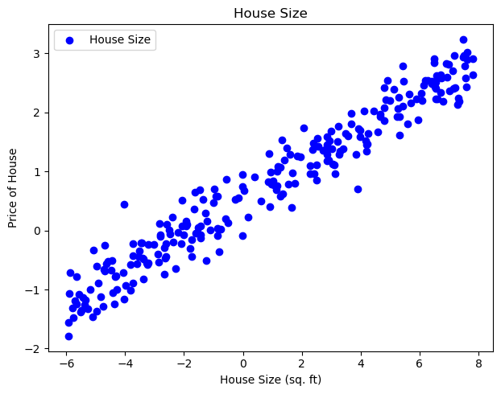

```python
np.random.seed(42)
n_samples = 250  # Number of data points per city

# Pre-defined parameters
true_alpha = 0.5  # True intercepts for each city
true_beta = 0.3     # True slopes for each city
true_sigma = 0.3

# Generate synthetic data
simulated_house_size = stats.uniform.rvs(-6, 14, n_samples)
mu = true_alpha + true_beta * simulated_house_size
simulated_price_standardized = stats.norm.rvs(mu, true_sigma, n_samples)


# Create a DataFrame for easier manipulation
simulated_data = pd.DataFrame({
    'simulated_house_size': simulated_house_size,
    'simulated_price_standardized': simulated_price_standardized
})

plt.figure(figsize=(12, 5))

# Scatter plot for house_size
plt.subplot(1, 2, 1)
plt.scatter(simulated_data['simulated_house_size'], simulated_data['simulated_price_standardized'], color='blue', label='House Size')
plt.title('House Size')
plt.xlabel('House Size (sq. ft)')
plt.ylabel('Price of House')
plt.legend()

# Display the plots
plt.tight_layout()
plt.show()
```

```python
# PyMC model for simulated data
with pm.Model() as simulated_model:

    alpha = pm.Normal('alpha', mu=1, sigma=1.5)
    beta = pm.Normal('beta', mu=1, sigma=1)
    sigma = pm.Exponential('sigma', 1)

    # Linear model
    mu = alpha + beta * simulated_data['simulated_house_size']

    # Likelihood
    pred = pm.Normal('p', mu=mu, sigma=sigma, observed=simulated_data['simulated_price_standardized'])

    # Inference
    simulated_idata= pm.sample(idata_kwargs={"log_likelihood": True})
```

```
Auto-assigning NUTS sampler...
Initializing NUTS using jitter+adapt_diag...
Multiprocess sampling (4 chains in 4 jobs)
NUTS: [alpha, beta, sigma]
```

```
Output()
```

```
Sampling 4 chains for 1_000 tune and 1_000 draw iterations (4_000 + 4_000 draws total) took 13 seconds.
```

```python
az.summary(simulated_idata)
# true_alpha = 0.5
# true_beta = 0.3
# true_sigma = 0.3
```

|  | mean | sd | hdi_3% | hdi_97% | mcse_mean | mcse_sd | ess_bulk | ess_tail | r_hat |
| --- | --- | --- | --- | --- | --- | --- | --- | --- | --- |
| alpha | 0.524 | 0.020 | 0.487 | 0.561 | 0.0 | 0.0 | 5333.0 | 3182.0 | 1.0 |
| beta | 0.295 | 0.005 | 0.286 | 0.304 | 0.0 | 0.0 | 5706.0 | 3026.0 | 1.0 |
| sigma | 0.300 | 0.014 | 0.272 | 0.324 | 0.0 | 0.0 | 6052.0 | 3517.0 | 1.0 |

### Posterior Model

```python
with pm.Model() as model:
    a = pm.Normal('a', mu = 1, sigma = 1.5, shape = n_cities)
    b = pm.LogNormal('b', mu = 1, sigma = 1, shape = n_cities)
    sigma = pm.Exponential('sigma', 1)
    mu = a[city] + b[city] * house_size_standardized
    pred_price = pm.Normal('p', mu = mu, sigma = sigma, observed = price_standardized)

    idata = pm.sample(idata_kwargs={"log_likelihood": True})
```

```
Auto-assigning NUTS sampler...
Initializing NUTS using jitter+adapt_diag...
Multiprocess sampling (4 chains in 4 jobs)
NUTS: [a, b, sigma]
```

```
Output()
```

```
Sampling 4 chains for 1_000 tune and 1_000 draw iterations (4_000 + 4_000 draws total) took 72 seconds.
```

```python
az.summary(idata)
```

|  | mean | sd | hdi_3% | hdi_97% | mcse_mean | mcse_sd | ess_bulk | ess_tail | r_hat |
| --- | --- | --- | --- | --- | --- | --- | --- | --- | --- |
| a[0] | -0.153 | 0.005 | -0.162 | -0.144 | 0.0 | 0.0 | 10693.0 | 3023.0 | 1.0 |
| a[1] | -0.231 | 0.006 | -0.242 | -0.219 | 0.0 | 0.0 | 9671.0 | 3014.0 | 1.0 |
| a[2] | -0.513 | 0.004 | -0.521 | -0.507 | 0.0 | 0.0 | 8364.0 | 3202.0 | 1.0 |
| a[3] | -0.573 | 0.005 | -0.583 | -0.563 | 0.0 | 0.0 | 8494.0 | 2535.0 | 1.0 |
| a[4] | 0.989 | 0.006 | 0.978 | 1.001 | 0.0 | 0.0 | 8588.0 | 3280.0 | 1.0 |
| a[5] | 0.431 | 0.006 | 0.420 | 0.442 | 0.0 | 0.0 | 9101.0 | 3357.0 | 1.0 |
| a[6] | 1.705 | 0.006 | 1.693 | 1.717 | 0.0 | 0.0 | 9568.0 | 3200.0 | 1.0 |
| a[7] | -0.320 | 0.006 | -0.330 | -0.309 | 0.0 | 0.0 | 8329.0 | 3286.0 | 1.0 |
| a[8] | 0.029 | 0.006 | 0.018 | 0.040 | 0.0 | 0.0 | 10751.0 | 2714.0 | 1.0 |
| a[9] | -0.336 | 0.006 | -0.346 | -0.325 | 0.0 | 0.0 | 9911.0 | 3307.0 | 1.0 |
| b[0] | 0.605 | 0.005 | 0.596 | 0.614 | 0.0 | 0.0 | 8872.0 | 2985.0 | 1.0 |
| b[1] | 0.700 | 0.006 | 0.689 | 0.712 | 0.0 | 0.0 | 8859.0 | 2924.0 | 1.0 |
| b[2] | 0.690 | 0.004 | 0.682 | 0.697 | 0.0 | 0.0 | 7729.0 | 3460.0 | 1.0 |
| b[3] | 0.665 | 0.007 | 0.652 | 0.677 | 0.0 | 0.0 | 10106.0 | 2862.0 | 1.0 |
| b[4] | 0.516 | 0.005 | 0.507 | 0.524 | 0.0 | 0.0 | 8512.0 | 3216.0 | 1.0 |
| b[5] | 0.605 | 0.006 | 0.594 | 0.616 | 0.0 | 0.0 | 8331.0 | 2805.0 | 1.0 |
| b[6] | 0.644 | 0.004 | 0.635 | 0.651 | 0.0 | 0.0 | 8722.0 | 3085.0 | 1.0 |
| b[7] | 0.573 | 0.006 | 0.560 | 0.585 | 0.0 | 0.0 | 8637.0 | 2981.0 | 1.0 |
| b[8] | 0.573 | 0.007 | 0.560 | 0.586 | 0.0 | 0.0 | 10446.0 | 3195.0 | 1.0 |
| b[9] | 0.599 | 0.008 | 0.585 | 0.614 | 0.0 | 0.0 | 9251.0 | 2817.0 | 1.0 |
| sigma | 0.530 | 0.001 | 0.528 | 0.532 | 0.0 | 0.0 | 8501.0 | 2453.0 | 1.0 |

```
array([[<Axes: title={'center': 'a\n0'}>,
        <Axes: title={'center': 'a\n0'}>],
       [<Axes: title={'center': 'a\n1'}>,
        <Axes: title={'center': 'a\n1'}>],
       [<Axes: title={'center': 'a\n2'}>,
        <Axes: title={'center': 'a\n2'}>],
       [<Axes: title={'center': 'a\n3'}>,
        <Axes: title={'center': 'a\n3'}>],
       [<Axes: title={'center': 'a\n4'}>,
        <Axes: title={'center': 'a\n4'}>],
       [<Axes: title={'center': 'a\n5'}>,
        <Axes: title={'center': 'a\n5'}>],
       [<Axes: title={'center': 'a\n6'}>,
        <Axes: title={'center': 'a\n6'}>],
       [<Axes: title={'center': 'a\n7'}>,
        <Axes: title={'center': 'a\n7'}>],
       [<Axes: title={'center': 'a\n8'}>,
        <Axes: title={'center': 'a\n8'}>],
       [<Axes: title={'center': 'a\n9'}>,
        <Axes: title={'center': 'a\n9'}>]], dtype=object)
```

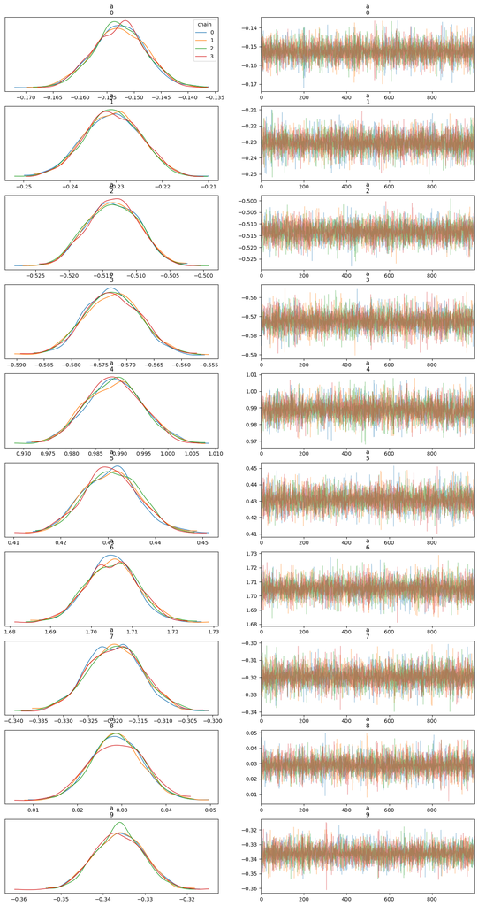

```python
az.plot_trace(idata, var_names=["a"], legend=True, figsize=(16,30), compact=False)
```

```
array([[<Axes: title={'center': 'a\n0'}>,
        <Axes: title={'center': 'a\n0'}, xlabel='Rank (all chains)', ylabel='Chain'>],
       [<Axes: title={'center': 'a\n1'}>,
        <Axes: title={'center': 'a\n1'}, xlabel='Rank (all chains)', ylabel='Chain'>],
       [<Axes: title={'center': 'a\n2'}>,
        <Axes: title={'center': 'a\n2'}, xlabel='Rank (all chains)', ylabel='Chain'>],
       [<Axes: title={'center': 'a\n3'}>,
        <Axes: title={'center': 'a\n3'}, xlabel='Rank (all chains)', ylabel='Chain'>],
       [<Axes: title={'center': 'a\n4'}>,
        <Axes: title={'center': 'a\n4'}, xlabel='Rank (all chains)', ylabel='Chain'>],
       [<Axes: title={'center': 'a\n5'}>,
        <Axes: title={'center': 'a\n5'}, xlabel='Rank (all chains)', ylabel='Chain'>],
       [<Axes: title={'center': 'a\n6'}>,
        <Axes: title={'center': 'a\n6'}, xlabel='Rank (all chains)', ylabel='Chain'>],
       [<Axes: title={'center': 'a\n7'}>,
        <Axes: title={'center': 'a\n7'}, xlabel='Rank (all chains)', ylabel='Chain'>],
       [<Axes: title={'center': 'a\n8'}>,
        <Axes: title={'center': 'a\n8'}, xlabel='Rank (all chains)', ylabel='Chain'>],
       [<Axes: title={'center': 'a\n9'}>,
        <Axes: title={'center': 'a\n9'}, xlabel='Rank (all chains)', ylabel='Chain'>]],
      dtype=object)
```

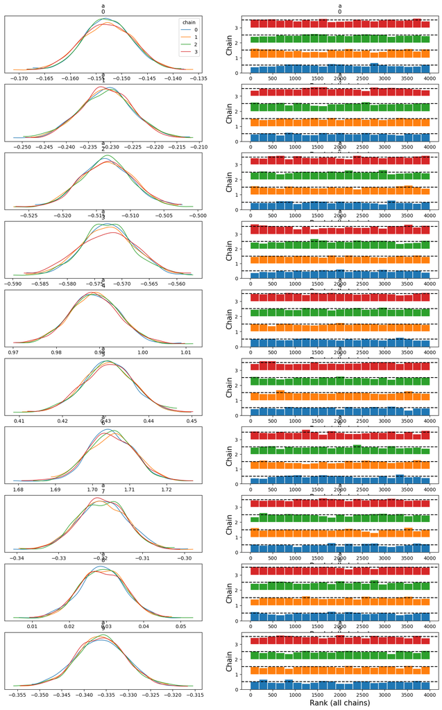

```python
az.plot_trace(idata, var_names=["a"], legend=True, compact=False, kind="rank_bars", figsize=(16,25))
```

### Model Results Characteristics

- The Chains are stationary and stay within high-probablility region of distribution.
- The Chain explores the full region of posterior from beginning of the trace.
- The Chains stay in the same high probability region.
- In the bar plots, The distribution of the bar plots is relatively uniform.
- Almost all parameters have a very high estimate of number of effective samples.

### Posterior Predective Check

```python
size_sequence = np.arange(-6, 8)
idata_thinned = az.extract(idata, num_samples= 1000)

mu_pred = np.zeros((n_cities, len(size_sequence), idata_thinned.sizes['sample']))
mu_ob = np.zeros((n_cities, len(house_size_standardized), idata_thinned.sizes['sample']))

a_values = idata_thinned.a.values
b_values = idata_thinned.b.values

for i, h in enumerate(size_sequence):
    for j in range(10):
        mu_pred[j][i] = a_values[j] + b_values[j] * h

for i, h in enumerate(house_size_standardized):
    for j in range(10):
        mu_ob[j][i] = stats.norm.rvs(a_values[j] + b_values[j] * h)

# mu_mean = mu_pred.mean(1)
```

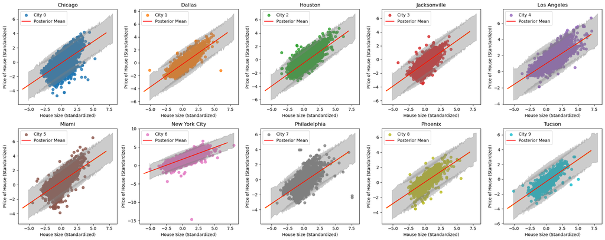

```python
unique_cities = np.unique(city)
n_cities = len(unique_cities)

rows = 2
cols = 5

plt.figure(figsize=(20, 8))

for i, city_code in enumerate(unique_cities):

    city_mask = city == city_code
    x_city = house_size_standardized[city_mask]
    y_city = price_standardized[city_mask]

    city_mean = mu_pred[city_code].mean(axis=-1)

    plt.subplot(rows, cols, i + 1)
    plt.scatter(x_city, y_city, color=plt.cm.tab10(city_code), label=f'City {city_code}', alpha=0.8)

    plt.plot(size_sequence, city_mean, color="red", label="Posterior Mean")
    az.plot_hdi(
        size_sequence,
        mu_pred[city_code].T,
        hdi_prob=0.95,
        color='yellow',
        fill_kwargs={"alpha": 0.4},
        smooth=False)
    az.plot_hdi(
        house_size_standardized,
        mu_ob[city_code].T,  # Transpose to match (samples, sequence) structure
        hdi_prob=0.95,
        color="gray",
        fill_kwargs={"alpha": 0.4},
        smooth=False
    )

    plt.title(f'{city_categories[city_code]}')
    plt.xlabel('House Size (Standardized)')
    plt.ylabel('Price of House (Standardized)')
    plt.legend()

# Adjust layout
plt.tight_layout()
plt.show()
```

### Discussion

The analysis revealed a clear trend: house prices generally increase with an increase in house size, as expected. This relationship was consistent across most cities, affirming the intuitive understanding that larger homes command higher market values. Additionally, the model highlighted the influence of city-specific factors, with house prices being significantly higher in more expensive cities. This finding aligns with real-world market dynamics, where geographic and economic factors drive property values in premium locations. By including City as a confounder, the model effectively disentangled the effect of house size on price from city-level variations, providing a more accurate estimate of the causal relationship.

#### Future Considerations

To further enrich the study, other potential confounders such as the number of bedrooms and bathrooms can be incorporated into the model. These features are critical components of housing valuation, as homes with more bedrooms and bathrooms often appeal to larger families or buyers seeking premium amenities, potentially driving higher prices. Including these additional confounders would allow for a more comprehensive understanding of how various property features contribute to pricing. It would also enable a comparative analysis between the effects of house size, bedrooms, and bathrooms on price, offering insights into which factors have the most significant impact.

#### Extended Analysis

Such an extended analysis could reveal interactions between these confounders as well—such as whether larger houses with fewer bedrooms or bathrooms exhibit different price trends compared to smaller houses with better amenities.